# Assignment 10 – Sentiment Analysis

Matthew Lucich

```r
library(tidyverse)
library(ggplot2)
library(tidytext)
library(textdata)
library(janeaustenr)
library(gutenbergr)
library(SentimentAnalysis)
```

## Overview

The objective was to re-create the code supplied in chapter 2 of *Text Mining with R*, then to extend the exercise with a new corpus and lexicon. Recreating the analysis in chapter 2 came with no issues, thanks to the thorough steps provided by the textbook. Extending the analysis brought up some issues with dealing with the text formatting, particularly finding the right regex to partition chapters in the new corpus. Finding an additional lexicon to utilize in the exercise was straightforward as the SentimentAnalysis R package came equipped with multiple dictionaries, of which we used the Harvard-IV dictionary.

### Tidy text: Jane Austen books

```r
tidy_books <- austen_books() %>%
  group_by(book) %>%
  mutate(
    linenumber = row_number(),
    chapter = cumsum(str_detect(text,
                                regex("^chapter [\\divxlc]",
                                      ignore_case = TRUE)))) %>%
  ungroup() %>%
  unnest_tokens(word, text)

head(tidy_books)
```

```
## # A tibble: 6 x 4
##   book                linenumber chapter word
##   <fct>                    <int>   <int> <chr>
## 1 Sense & Sensibility          1       0 sense
## 2 Sense & Sensibility          1       0 and
## 3 Sense & Sensibility          1       0 sensibility
## 4 Sense & Sensibility          3       0 by
## 5 Sense & Sensibility          3       0 jane
## 6 Sense & Sensibility          3       0 austen
```

### Tidy text: Baruch Spinoza books

```r
# Download Ethics by Spinoza from gutenbergr
ethics_raw <- gutenberg_download(3800)
ethics <- as_tibble(ethics_raw)
ethics <- ethics %>% add_column(book = "Ethics")

# Download Theologico-Political by Spinoza from gutenbergr
theologico_prt1_raw <- gutenberg_download(989)
theologico_prt1 <- as_tibble(theologico_prt1_raw)
theologico_prt1 <- theologico_prt1 %>% add_column(book = "Theologico-Political Part 1")

# Concat Spinoza books into one dataframe
spinoza_books_raw <- bind_rows(ethics, theologico_prt1)

# Tokenize the text so that each word is its own row
spinoza_books <- spinoza_books_raw %>%
  group_by(book) %>%
  mutate(
    linenumber = row_number(),
    chapter = cumsum(str_detect(text,
                                regex("PART|Chapter|CHAPTER  [\\dIVXLC]")))) %>%
  ungroup() %>%
  unnest_tokens(word, text)

tail(spinoza_books)
```

```
## # A tibble: 6 x 5
##   gutenberg_id book                        linenumber chapter word
##          <int> <chr>                            <int>   <int> <chr>
## 1          989 Theologico-Political Part 1       2853       5 end
## 2          989 Theologico-Political Part 1       2853       5 of
## 3          989 Theologico-Political Part 1       2853       5 endnotes
## 4          989 Theologico-Political Part 1       2853       5 to
## 5          989 Theologico-Political Part 1       2853       5 part
## 6          989 Theologico-Political Part 1       2853       5 i
```

## Filter for words by sentiment using nrc: Emma, by Jane Austen

```r
nrc_joy <- get_sentiments("nrc") %>%
  filter(sentiment == "joy")

tidy_books %>%
  filter(book == "Emma") %>%
  inner_join(nrc_joy) %>%
  count(word, sort = TRUE)
```

```
## # A tibble: 303 x 2
##    word        n
##    <chr>   <int>
##  1 good      359
##  2 young     192
##  3 friend    166
##  4 hope      143
##  5 happy     125
##  6 love      117
##  7 deal       92
##  8 found      92
##  9 present    89
## 10 kind       82
## # … with 293 more rows
```

## Filter for words by sentiment using Harvard-IV: Ethics, by Baruch Spinoza

```r
# Filter for words with positive sentiment
# Note: DictionaryGI is Harvard-IV dictionary from SentimentAnalysis
gi_positive <- as_tibble(DictionaryGI$positive)
gi_positive <- gi_positive %>% rename(word = value)

# Filter for words with negative sentiment (DictionaryGI is from SentimentAnalysis)
gi_negative <- as_tibble(DictionaryGI$negative)
gi_negative <- gi_negative %>% rename(word = value)

# Inner join words from Ethics and positive words from Harvard-IV lexicon
spinoza_positive <- spinoza_books %>%
                        filter(book == "Ethics") %>%
                        inner_join(gi_positive) %>%
                        count(word, sort = TRUE)

head(spinoza_positive)
```

```
## # A tibble: 6 x 2
##   word          n
##   <chr>     <int>
## 1 mind        580
## 2 human       294
## 3 love        251
## 4 pleasure    213
## 5 knowledge   208
## 6 good        181
```

### Count positive vs negative words in 80 line sections: Jane Austen

```r
jane_austen_sentiment <- tidy_books %>%
  inner_join(get_sentiments("bing")) %>%
  count(book, index = linenumber %/% 80, sentiment) %>%
  pivot_wider(names_from = sentiment, values_from = n, values_fill = 0) %>%
  mutate(sentiment = positive - negative)

head(jane_austen_sentiment)
```

```
## # A tibble: 6 x 5
##   book                index negative positive sentiment
##   <fct>               <dbl>    <int>    <int>     <int>
## 1 Sense & Sensibility     0       16       32        16
## 2 Sense & Sensibility     1       19       53        34
## 3 Sense & Sensibility     2       12       31        19
## 4 Sense & Sensibility     3       15       31        16
## 5 Sense & Sensibility     4       16       34        18
## 6 Sense & Sensibility     5       16       51        35
```

### Count positive vs negative words in 80 line sections: Baruch Spinoza

```r
# Add column indicating sentiment (needed in long format)
gi_positive_df <- gi_positive %>% add_column(sentiment = "positive")
gi_negative_df <- gi_negative %>% add_column(sentiment = "negative")

# Concat positive and negative words into one dataframe
gi_dict <- bind_rows(gi_positive_df, gi_negative_df)

# Evaluate sentiment 80 lines at a time
spinoza_sentiment <- spinoza_books %>%
  inner_join(gi_dict) %>%
  count(book, index = linenumber %/% 80, sentiment) %>%
  pivot_wider(names_from = sentiment, values_from = n, values_fill = 0) %>%
  mutate(sentiment = positive - negative)

head(spinoza_sentiment)
```

```
## # A tibble: 6 x 5
##   book   index negative positive sentiment
##   <chr>  <dbl>    <int>    <int>     <int>
## 1 Ethics     0        8       11         3
## 2 Ethics     1        9       18         9
## 3 Ethics     2       19       47        28
## 4 Ethics     3       12       23        11
## 5 Ethics     4       23       26         3
## 6 Ethics     5       13       14         1
```

### Plot sentiment by book: Jane Austen

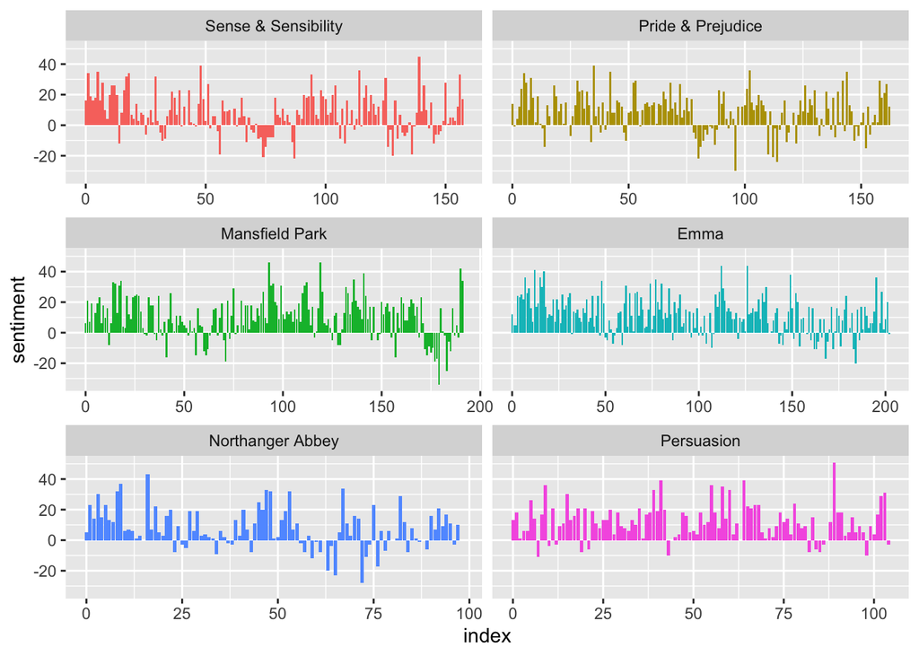

```r
ggplot(jane_austen_sentiment, aes(index, sentiment, fill = book)) +
  geom_col(show.legend = FALSE) +
  facet_wrap(~book, ncol = 2, scales = "free_x")
```

### Plot sentiment by book: Baruch Spinoza

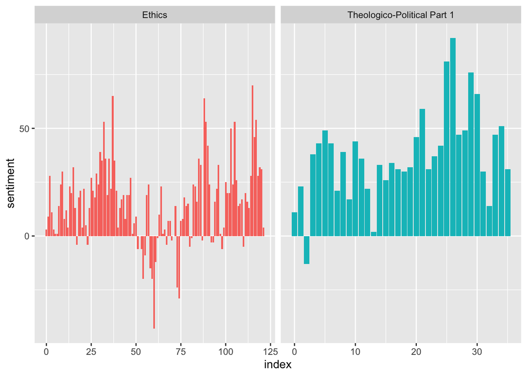

```r
# View net sentiment over the course of the book
ggplot(spinoza_sentiment, aes(index, sentiment, fill = book)) +
  geom_col(show.legend = FALSE) +
  facet_wrap(~book, ncol = 2, scales = "free_x")
```

### Comparing sentiment classification across lexicons: Pride & Prejudice

[figure not shown]

```r
pride_prejudice <- tidy_books %>%
  filter(book == "Pride & Prejudice")

afinn <- pride_prejudice %>%
  inner_join(get_sentiments("afinn")) %>%
  group_by(index = linenumber %/% 80) %>%
  summarise(sentiment = sum(value)) %>%
  mutate(method = "AFINN")

bing_and_nrc <- bind_rows(
  pride_prejudice %>%
    inner_join(get_sentiments("bing")) %>%
    mutate(method = "Bing et al."),
  pride_prejudice %>%
    inner_join(gi_dict %>%
                 filter(sentiment %in% c("positive",
                                         "negative"))
    ) %>%
    mutate(method = "NRC")) %>%
  count(method, index = linenumber %/% 80, sentiment) %>%
  pivot_wider(names_from = sentiment,
              values_from = n,
              values_fill = 0) %>%
  mutate(sentiment = positive - negative)

bind_rows(afinn,
          bing_and_nrc) %>%
  ggplot(aes(index, sentiment, fill = method)) +
  geom_col(show.legend = FALSE) +
  facet_wrap(~method, ncol = 1, scales = "free_y")
```

### Comparing sentiment classification across lexicons: Ethics

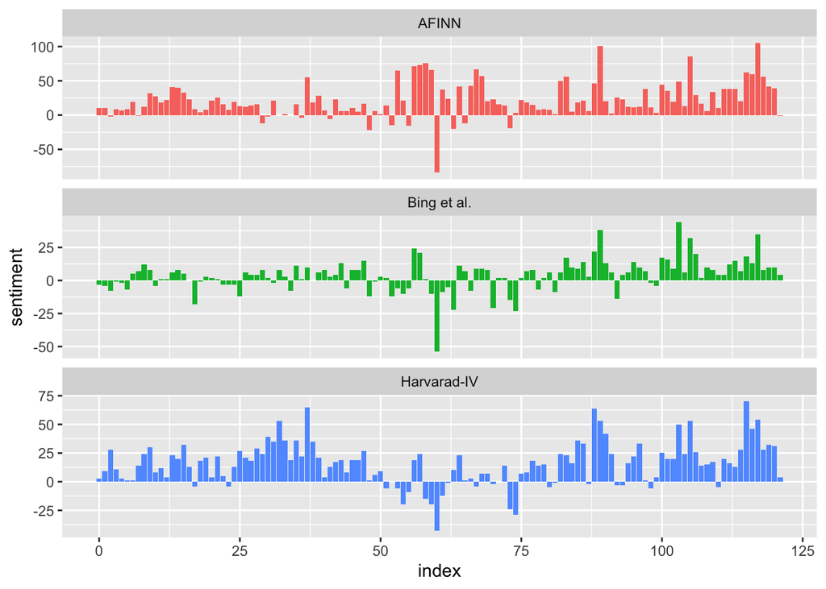

```r
ethics_book <- spinoza_books %>%
                        filter(book == "Ethics")

afinn <- ethics_book %>%
  inner_join(get_sentiments("afinn")) %>%
  group_by(index = linenumber %/% 80) %>%
  summarise(sentiment = sum(value)) %>%
  mutate(method = "AFINN")

bing_and_nrc <- bind_rows(
  ethics_book %>%
    inner_join(get_sentiments("bing")) %>%
    mutate(method = "Bing et al."),
  ethics_book %>%
    inner_join(gi_dict %>%
                 filter(sentiment %in% c("positive",
                                         "negative"))
    ) %>%
    mutate(method = "Harvarad-IV")) %>%
  count(method, index = linenumber %/% 80, sentiment) %>%
  pivot_wider(names_from = sentiment,
              values_from = n,
              values_fill = 0) %>%
  mutate(sentiment = positive - negative)

bind_rows(afinn,
          bing_and_nrc) %>%
  ggplot(aes(index, sentiment, fill = method)) +
  geom_col(show.legend = FALSE) +
  facet_wrap(~method, ncol = 1, scales = "free_y")
```

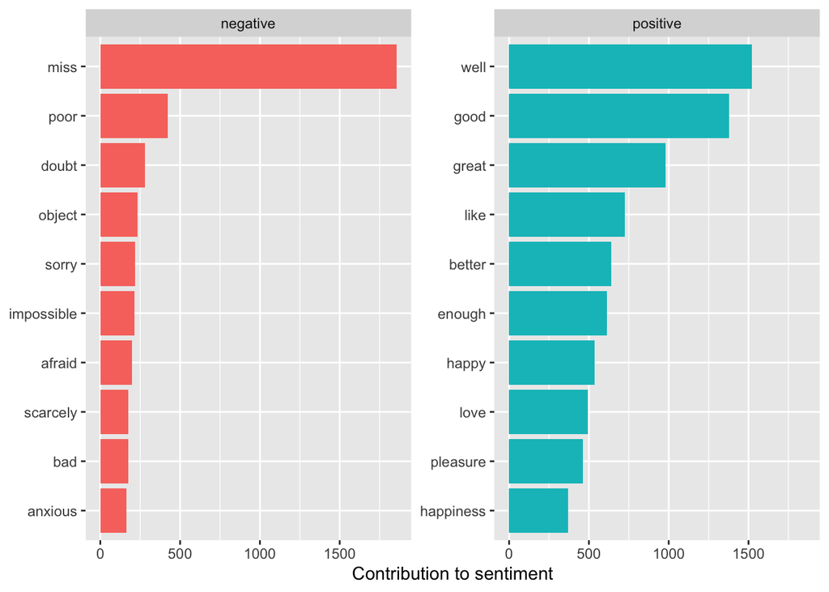

```r
bing_word_counts <- tidy_books %>%
  inner_join(get_sentiments("bing")) %>%
  count(word, sentiment, sort = TRUE) %>%
  ungroup()

bing_word_counts %>%
  group_by(sentiment) %>%
  slice_max(n, n = 10) %>%
  ungroup() %>%
  mutate(word = reorder(word, n)) %>%
  ggplot(aes(n, word, fill = sentiment)) +
  geom_col(show.legend = FALSE) +
  facet_wrap(~sentiment, scales = "free_y") +
  labs(x = "Contribution to sentiment",
       y = NULL)
```

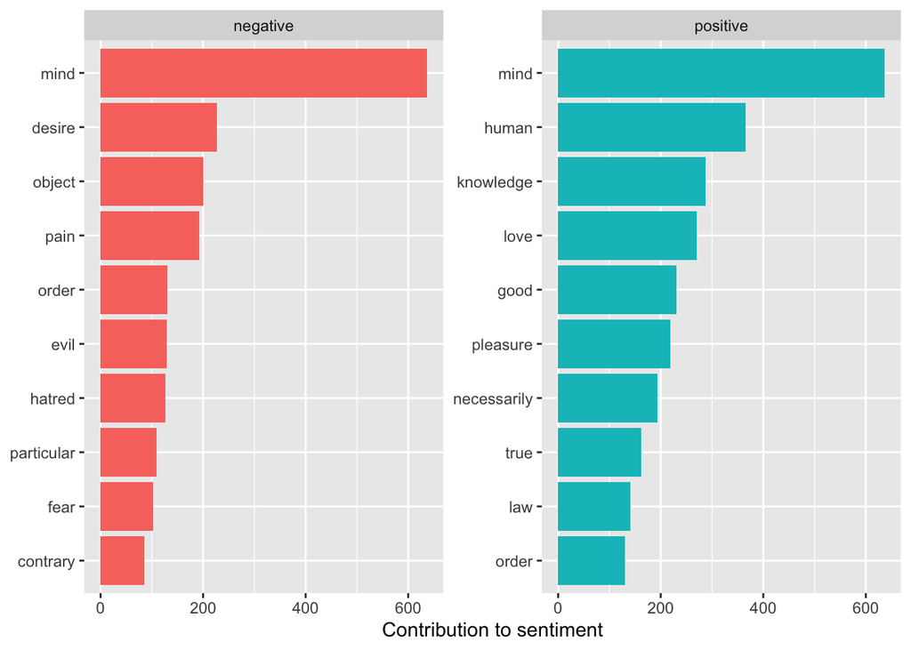

```r
# Label the sentiment of each word
gi_word_counts <- spinoza_books %>%
  inner_join(gi_dict) %>%
  count(word, sentiment, sort = TRUE) %>%
  ungroup()

# Plot top negative and positive words by count
gi_word_counts %>%
  group_by(sentiment) %>%
  slice_max(n, n = 10) %>%
  ungroup() %>%
  mutate(word = reorder(word, n)) %>%
  ggplot(aes(n, word, fill = sentiment)) +
  geom_col(show.legend = FALSE) +
  facet_wrap(~sentiment, scales = "free_y") +
  labs(x = "Contribution to sentiment",
       y = NULL)
```

### Add custom stop words: Jane Austen

```r
custom_stop_words_ja <- bind_rows(tibble(word = c("miss"),
                                      lexicon = c("custom")),
                               stop_words)

custom_stop_words_ja
```

```
## # A tibble: 1,150 x 2
##    word        lexicon
##    <chr>       <chr>
##  1 miss        custom
##  2 a           SMART
##  3 a's         SMART
##  4 able        SMART
##  5 about       SMART
##  6 above       SMART
##  7 according   SMART
##  8 accordingly SMART
##  9 across      SMART
## 10 actually    SMART
## # … with 1,140 more rows
```

### Add custom stop words: Baruch Spinoza

```r
custom_stop_words_sp <- bind_rows(tibble(word = c("mind", "order"),
                                      lexicon = c("custom", "custom")),
                               stop_words)

custom_stop_words_sp
```

```
## # A tibble: 1,151 x 2
##    word        lexicon
##    <chr>       <chr>
##  1 mind        custom
##  2 order       custom
##  3 a           SMART
##  4 a's         SMART
##  5 able        SMART
##  6 about       SMART
##  7 above       SMART
##  8 according   SMART
##  9 accordingly SMART
## 10 across      SMART
## # … with 1,141 more rows
```

### Sentence and chapter tokenization: Pride & Prejudice

```r
p_and_p_sentences <- tibble(text = prideprejudice) %>%
  unnest_tokens(sentence, text, token = "sentences")

austen_chapters <- austen_books() %>%
  group_by(book) %>%
  unnest_tokens(chapter, text, token = "regex",
                pattern = "Chapter|CHAPTER [\\dIVXLC]") %>%
  ungroup()

austen_chapters %>%
  group_by(book) %>%
  summarise(chapters = n())
```

```
## # A tibble: 6 x 2
##   book                chapters
## * <fct>                  <int>
## 1 Sense & Sensibility       51
## 2 Pride & Prejudice         62
## 3 Mansfield Park            49
## 4 Emma                      56
## 5 Northanger Abbey          32
## 6 Persuasion                25
```

### Sentence and chapter tokenization: Ethics

```r
ethics_text <- spinoza_books_raw %>%
                        filter(book == "Ethics")

# Tokenize chapters with regex
spinoza_chapters <- spinoza_books_raw %>%
  group_by(book) %>%
  unnest_tokens(chapter, text, token = "regex",
                pattern = "PART|Chapter|CHAPTER  [\\dIVXLC]") %>%
                ungroup()

# Confirm chapters were partitioned correctly
spinoza_chapters %>%
  group_by(book) %>%
  summarise(chapters = n())
```

```
## # A tibble: 2 x 2
##   book                        chapters
## * <chr>                          <int>
## 1 Ethics                             5
## 2 Theologico-Political Part 1        6
```

### Negative word ratio: Jane Austen

```r
bingnegative <- get_sentiments("bing") %>%
  filter(sentiment == "negative")

wordcounts <- tidy_books %>%
  group_by(book, chapter) %>%
  summarize(words = n())

tidy_books %>%
  semi_join(bingnegative) %>%
  group_by(book, chapter) %>%
  summarize(negativewords = n()) %>%
  left_join(wordcounts, by = c("book", "chapter")) %>%
  mutate(ratio = negativewords/words) %>%
  filter(chapter != 0) %>%
  slice_max(ratio, n = 1) %>%
  ungroup()
```

```
## # A tibble: 6 x 5
##   book                chapter negativewords words  ratio
##   <fct>                 <int>         <int> <int>  <dbl>
## 1 Sense & Sensibility      43           161  3405 0.0473
## 2 Pride & Prejudice        34           111  2104 0.0528
## 3 Mansfield Park           46           173  3685 0.0469
## 4 Emma                     15           151  3340 0.0452
## 5 Northanger Abbey         21           149  2982 0.0500
## 6 Persuasion                4            62  1807 0.0343
```

### Positive word ratio: Baruch Spinoza

```r
bingpositive <- gi_dict %>%
  filter(sentiment == "positive")

# Word count of each chapter
wordcounts_sp <- spinoza_books %>%
  group_by(book, chapter) %>%
  summarize(words = n())

# Highest positive word ratio of each book
spinoza_books %>%
  semi_join(bingpositive) %>%
  group_by(book, chapter) %>%
  summarize(positivewords = n()) %>%
  left_join(wordcounts_sp, by = c("book", "chapter")) %>%
  mutate(ratio = positivewords/words) %>%
  slice_max(ratio, n = 1) %>%
  ungroup()
```

```
## # A tibble: 2 x 5
##   book                        chapter positivewords words  ratio
##   <chr>                         <int>         <int> <int>  <dbl>
## 1 Ethics                            4           770 10915 0.0705
## 2 Theologico-Political Part 1       2            47   415 0.113
```

## Conclusion

Again, the meticulous documentation by *Text Mining with R* made re-creating the primary code functions seamless. There are two main takeaways from extending the sentiment analysis. One, this task once again proves that the majority of a data scientists time will be formatting the data. Two, these analyses will need customization. For example, many of the positive and negative sentiment words are questionable in the context of this text. When looking to build sentiment analysis into a production application, thorough review of the dictionaries being used will be required. Additionally, the data scientist should consider using a domain-specific lexicon when possible. While all the lexicons used in this analysis had their weak points, AFINN seems to be the strongest as it offers degrees of positive and negative sentiment.

....

## References

Julia Silge and David Robinson (2017) [Chapter 2, Text Mining with R](https://www.tidytextmining.com/sentiment.html)

David Robinson (2020). gutenbergr: Search and download public domain texts from Project Gutenberg. R package version 0.2.0.

Stefan Feuerriegel, Nicolas Proellochs (2021). SentimentAnalysis: a powerful toolchain facilitating the sentiment analysis of textual contents in R. R package version 1.3-4.

This work is licensed under a [Creative Commons Attribution-ShareAlike 4.0 International License](http://creativecommons.org/licenses/by-sa/4.0/).